# Investigate TMDB 5000 Movie Dataset

- Introduction
- Data Wrangling
- Exploratory Data Analysis
- Conclusions

## Introduction

> This dataset was originally generated from The Movie Database(TMDb) API, and made available through Kaggle. The dataset contains several attributes and parameters on basis of which popularity and profitability of a film can be measured.

> This dataset contains information about 5000 movies, and related information such as budget spent, revenue made, cast and crews, total and average vote. In this analysis we will try to answer some of the following questions.
> 1. Which is the most/least popular movie (by title/popularity) ?
> 2. What is the oldest/latest released movie in dataset ?
> 3. Which movie made maximum/minimum revenue ?
> 4. Which movie had maximum/minimum budget?

```python
# import libraries
import pandas as pd
import numpy as np
import matplotlib.pyplot as plt
% matplotlib inline
```

## Data Wrangling

> As part of data wrangling step, we will load, clean and sanitize data as per analysis required to answer above questions.

### General Properties

```python
# Load data file for movies
df_movies=pd.read_csv('tmdb_5000_movies.csv')

# Check sample data
df_movies.head()
```

|  | budget | genres | homepage | id | keywords | original_language | original_title | overview | popularity | production_companies | production_countries | release_date | revenue | runtime | spoken_languages | status | tagline | title | vote_average | vote_count |
| --- | --- | --- | --- | --- | --- | --- | --- | --- | --- | --- | --- | --- | --- | --- | --- | --- | --- | --- | --- | --- |
| 0 | 237000000 | [{"id": 28, "name": "Action"}, {"id": 12, "nam... | http://www.avatarmovie.com/ | 19995 | [{"id": 1463, "name": "culture clash"}, {"id":... | en | Avatar | In the 22nd century, a paraplegic Marine is di... | 150.437577 | [{"name": "Ingenious Film Partners", "id": 289... | [{"iso_3166_1": "US", "name": "United States o... | 2009-12-10 | 2787965087 | 162.0 | [{"iso_639_1": "en", "name": "English"}, {"iso... | Released | Enter the World of Pandora. | Avatar | 7.2 | 11800 |
| 1 | 300000000 | [{"id": 12, "name": "Adventure"}, {"id": 14, "... | http://disney.go.com/disneypictures/pirates/ | 285 | [{"id": 270, "name": "ocean"}, {"id": 726, "na... | en | Pirates of the Caribbean: At World's End | Captain Barbossa, long believed to be dead, ha... | 139.082615 | [{"name": "Walt Disney Pictures", "id": 2}, {"... | [{"iso_3166_1": "US", "name": "United States o... | 2007-05-19 | 961000000 | 169.0 | [{"iso_639_1": "en", "name": "English"}] | Released | At the end of the world, the adventure begins. | Pirates of the Caribbean: At World's End | 6.9 | 4500 |
| 2 | 245000000 | [{"id": 28, "name": "Action"}, {"id": 12, "nam... | http://www.sonypictures.com/movies/spectre/ | 206647 | [{"id": 470, "name": "spy"}, {"id": 818, "name... | en | Spectre | A cryptic message from Bond’s past sends him o... | 107.376788 | [{"name": "Columbia Pictures", "id": 5}, {"nam... | [{"iso_3166_1": "GB", "name": "United Kingdom"... | 2015-10-26 | 880674609 | 148.0 | [{"iso_639_1": "fr", "name": "Fran\u00e7ais"},... | Released | A Plan No One Escapes | Spectre | 6.3 | 4466 |
| 3 | 250000000 | [{"id": 28, "name": "Action"}, {"id": 80, "nam... | http://www.thedarkknightrises.com/ | 49026 | [{"id": 849, "name": "dc comics"}, {"id": 853,... | en | The Dark Knight Rises | Following the death of District Attorney Harve... | 112.312950 | [{"name": "Legendary Pictures", "id": 923}, {"... | [{"iso_3166_1": "US", "name": "United States o... | 2012-07-16 | 1084939099 | 165.0 | [{"iso_639_1": "en", "name": "English"}] | Released | The Legend Ends | The Dark Knight Rises | 7.6 | 9106 |
| 4 | 260000000 | [{"id": 28, "name": "Action"}, {"id": 12, "nam... | http://movies.disney.com/john-carter | 49529 | [{"id": 818, "name": "based on novel"}, {"id":... | en | John Carter | John Carter is a war-weary, former military ca... | 43.926995 | [{"name": "Walt Disney Pictures", "id": 2}] | [{"iso_3166_1": "US", "name": "United States o... | 2012-03-07 | 284139100 | 132.0 | [{"iso_639_1": "en", "name": "English"}] | Released | Lost in our world, found in another. | John Carter | 6.1 | 2124 |

### Data Cleaning (Remove null, duplicates and unused information)

> 1. Remove unused columns
> 2. Remove duplicates values
> 3. Remove records where runtime, revenue and budget is zero
> 4. Check for datatypes of columns

#### 1. Remove unused columns

> Remove below mentioned columns genres,homepage,keywords,production_companies,production_countries,original_language,overview,spoken_languages,tagline

```python
#create a list of columns to delete
delete_col=['genres','homepage','keywords','production_companies','production_countries','original_language','overview','spoken_languages','tagline']

#deleting the unused columns
df_movies= df_movies.drop(delete_col,1)
```

```python
#previewing the new dataset
df_movies.head()
```

|  | budget | id | original_title | popularity | release_date | revenue | runtime | status | title | vote_average | vote_count |
| --- | --- | --- | --- | --- | --- | --- | --- | --- | --- | --- | --- |
| 0 | 237000000 | 19995 | Avatar | 150.437577 | 2009-12-10 | 2787965087 | 162.0 | Released | Avatar | 7.2 | 11800 |
| 1 | 300000000 | 285 | Pirates of the Caribbean: At World's End | 139.082615 | 2007-05-19 | 961000000 | 169.0 | Released | Pirates of the Caribbean: At World's End | 6.9 | 4500 |
| 2 | 245000000 | 206647 | Spectre | 107.376788 | 2015-10-26 | 880674609 | 148.0 | Released | Spectre | 6.3 | 4466 |
| 3 | 250000000 | 49026 | The Dark Knight Rises | 112.312950 | 2012-07-16 | 1084939099 | 165.0 | Released | The Dark Knight Rises | 7.6 | 9106 |
| 4 | 260000000 | 49529 | John Carter | 43.926995 | 2012-03-07 | 284139100 | 132.0 | Released | John Carter | 6.1 | 2124 |

#### 2. Remove duplicates

> Check for total number of rows and columns

```python
row,column = df_movies.shape
print("Total rows: {0} Total columns: {1}".format(row,column))
```

```
Total rows: 4803 Total columns: 11
```

> Check for duplicates

```python
sum(df_movies.duplicated())
```

```
0
```

> Even though there are no duplicates in this dataset,removing duplicates as a precautionary measure

```python
#Remove duplicates

df_movies.drop_duplicates(keep ='first', inplace=True)
row, column = df_movies.shape

print("Total rows: {0} Total columns: {1}".format(row,column))
```

```
Total rows: 4803 Total columns: 11
```

> Check unique values for all columns

```python
df_movies.nunique()
```

```
budget             436
id                4803
original_title    4801
popularity        4802
release_date      3280
revenue           3297
runtime            156
status               3
title             4800
vote_average        71
vote_count        1609
dtype: int64
```

#### 3. Remove records where runtime, budget and revenue is zero

```python
# creating a list of columns containings columns to be removed
remove_list=['budget', 'revenue','runtime']

#this will replace all the value from '0' to NAN in the list
df_movies[remove_list] = df_movies[remove_list].replace(0, np.NAN)

#Removing all the row which has NaN value in temp_list
df_movies.dropna(subset = remove_list, inplace = True)

rows, col = df_movies.shape
print('After removing such entries, we now have only {} no.of movies.'.format(rows))
```

```
After removing such entries, we now have only 3229 no.of movies.
```

#### 4. Convert datatype of columns to one which is more relevant

> Check data types of all columns

```python
df_movies.info()
```

```
<class 'pandas.core.frame.DataFrame'>
Int64Index: 3229 entries, 0 to 4798
Data columns (total 11 columns):
budget            3229 non-null float64
id                3229 non-null int64
original_title    3229 non-null object
popularity        3229 non-null float64
release_date      3229 non-null object
revenue           3229 non-null float64
runtime           3229 non-null float64
status            3229 non-null object
title             3229 non-null object
vote_average      3229 non-null float64
vote_count        3229 non-null int64
dtypes: float64(5), int64(2), object(4)
memory usage: 302.7+ KB
```

> Data type of release data should be date type

```python
df_movies.release_date = pd.to_datetime(df_movies['release_date'])
```

> Re-check data types of all columns

```python
df_movies.info()
```

```
<class 'pandas.core.frame.DataFrame'>
Int64Index: 3229 entries, 0 to 4798
Data columns (total 11 columns):
budget            3229 non-null float64
id                3229 non-null int64
original_title    3229 non-null object
popularity        3229 non-null float64
release_date      3229 non-null datetime64[ns]
revenue           3229 non-null float64
runtime           3229 non-null float64
status            3229 non-null object
title             3229 non-null object
vote_average      3229 non-null float64
vote_count        3229 non-null int64
dtypes: datetime64[ns](1), float64(5), int64(2), object(3)
memory usage: 302.7+ KB
```

## Exploratory Data Analysis

> In this section we will find out answers to all of our questions

### Define a common function to answer above research questions

```python
def return_movie(columnName):

    most_popular_movie=df_movies.loc[df_movies[columnName].idxmax()]['title']
    max_value=df_movies[columnName].max()

    least_popular_movie=df_movies.loc[df_movies[columnName].idxmin()]['title']
    min_value=df_movies[columnName].min()

    print("Movie {0} with maximum {1} {2}".format(most_popular_movie,columnName,max_value))
    print("Movie {0} with minimum {1} {2}".format(least_popular_movie,columnName,min_value))
```

### Define a function which returns average of a column

```python
#Function to find average
def return_avg(column):
    return df_movies[column].mean()
```

### First level of exploration for general trends

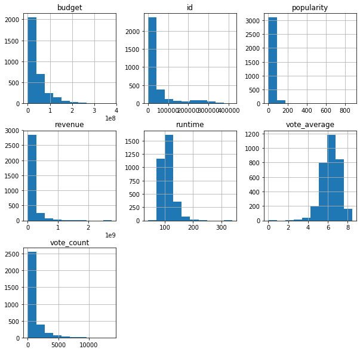

```python
#Initial exploration to see possible trends visually
df_movies.hist(figsize=(10,10));
```

### Research Question 1 (Most and least popular movie)

```python
return_movie('popularity')
```

```
Movie Minions with maximum popularity 875.581305
Movie Woman Thou Art Loosed with minimum popularity 0.019984000000000002
```

### Research Question 2 (Oldest and recent movie)

```python
return_movie('release_date')
```

```
Movie The Birth of a Nation with maximum release_date 2016-09-09 00:00:00
Movie Intolerance with minimum release_date 1916-09-04 00:00:00
```

### Research Question 3 (Movies with maximum and minimum revenue)

```python
return_movie('revenue')
```

```
Movie Avatar with maximum revenue 2787965087.0
Movie Split Second with minimum revenue 5.0
```

### Research Question 4 (Movies with maximum and minimum budget)

```python
return_movie('budget')
```

```
Movie Pirates of the Caribbean: On Stranger Tides with maximum budget 380000000.0
Movie Modern Times with minimum budget 1.0
```

### Research Question 5 (Movies which made maximum and minimum profit)

> Insert a new column names profit_earned

```python
df_movies.insert(2,'profit_earned',df_movies['revenue']-df_movies['budget'])
```

```python
return_movie('profit_earned')
```

```
Movie Avatar with maximum profit_earned 2550965087.0
Movie The Lone Ranger with minimum profit_earned -165710090.0
```

### Research Question 6 (Movies with maximum and minimum votes)

```python
return_movie('vote_count')
```

```
Movie Inception with maximum vote_count 13752
Movie Mi America with minimum vote_count 0
```

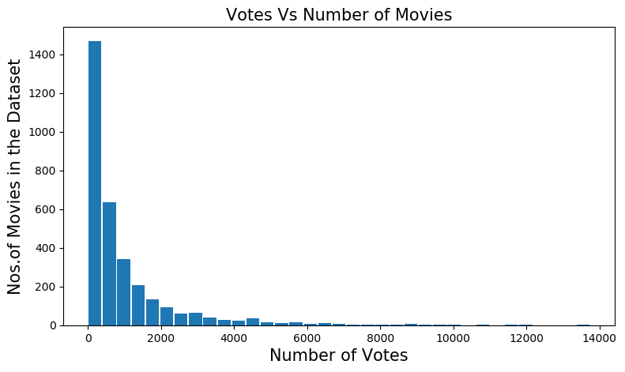

```python
#giving the figure size(width, height)
plt.figure(figsize=(9,5), dpi = 100)

#On x-axis
plt.xlabel('Number of Votes', fontsize = 15)
#On y-axis
plt.ylabel('Nos.of Movies in the Dataset', fontsize=15)
#Name of the graph
plt.title('Votes Vs Number of Movies', fontsize=15)

#giving a histogram plot
plt.hist(df_movies['vote_count'], rwidth = 0.9, bins =35)
#displays the plot
plt.show()
```

```python
df_movies['vote_count'].describe()
```

```
count     3229.000000
mean       977.287395
std       1414.309577
min          0.000000
25%        178.000000
50%        471.000000
75%       1148.000000
max      13752.000000
Name: vote_count, dtype: float64
```

### Research Question 7 (Movies with maximum and minimum average votes)

```python
return_movie('vote_average')
```

```
Movie The Shawshank Redemption with maximum vote_average 8.5
Movie Mi America with minimum vote_average 0.0
```

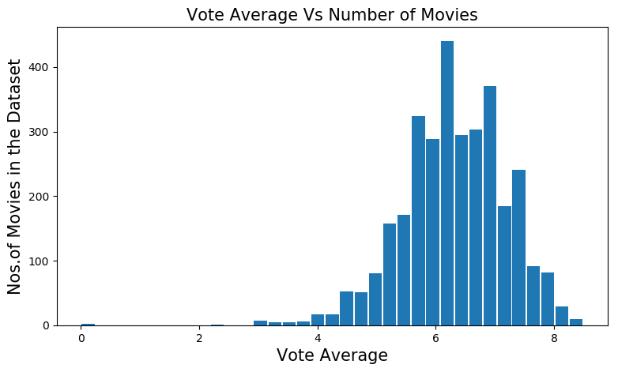

```python
#giving the figure size(width, height)
plt.figure(figsize=(9,5), dpi = 100)

#On x-axis
plt.xlabel('Vote Average', fontsize = 15)
#On y-axis
plt.ylabel('Nos.of Movies in the Dataset', fontsize=15)
#Name of the graph
plt.title('Vote Average Vs Number of Movies', fontsize=15)

#giving a histogram plot
plt.hist(df_movies['vote_average'], rwidth = 0.9, bins =35)
#displays the plot
plt.show()
```

```python
df_movies['vote_average'].describe()
```

```
count    3229.000000
mean        6.309353
std         0.873891
min         0.000000
25%         5.800000
50%         6.300000
75%         6.900000
max         8.500000
Name: vote_average, dtype: float64
```

### Research Question 8 (Find average runtime of all movies )

```python
return_avg('runtime')
```

```
110.72437287085785
```

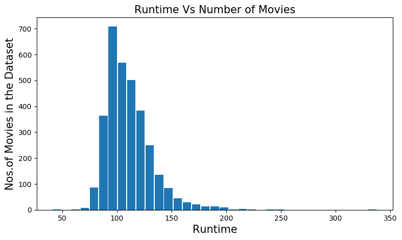

```python
#giving the figure size(width, height)
plt.figure(figsize=(9,5), dpi = 100)

#On x-axis
plt.xlabel('Runtime', fontsize = 15)
#On y-axis
plt.ylabel('Nos.of Movies in the Dataset', fontsize=15)
#Name of the graph
plt.title('Runtime Vs Number of Movies', fontsize=15)

#giving a histogram plot
plt.hist(df_movies['runtime'], rwidth = 0.9, bins =35)
#displays the plot
plt.show()
```

### Research Question 9 (Find average budget of all movies )

```python
return_avg('budget')
```

```
40654444.774233505
```

```python
return_avg('revenue')
```

```
121242957.26138124
```

### Research Question 10 (Find average profit of all movies )

```python
#df_movies.head()
return_avg('profit_earned')
```

```
80588512.48714772
```

### Research Question 11 (Identify revenue trends)

> > **Revenue Vs Popularity**

[figure not shown]

```python
import matplotlib.pyplot as plt
plt.scatter(x=df_movies['revenue'], y=df_movies['popularity'])
plt.xlabel('Popularity')
plt.ylabel('Revenue')
plt.title('Revenue vs Popularity Over the Years');
```

> > **Revenue Vs Vote Count**

[figure not shown]

```python
# Creating a scatterplot of revenue and vote counts over the years
plt.scatter(x=df_movies['revenue'], y=df_movies['vote_count'])
plt.xlabel('Vote Count')
plt.ylabel('Revenue')
plt.title('Revenue vs Vote Count Over the Years');
```

> > **Revenue Vs Budget**

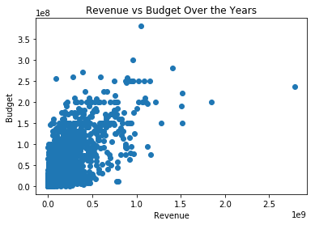

```python
# Creating a scatterplot of revenue and vote averages over the years
plt.scatter(x=df_movies['revenue'], y=df_movies['budget'])
plt.xlabel('Revenue')
plt.ylabel('Budget')
plt.title('Revenue vs Budget Over the Years');
```

> > **Revenue Vs Rumtime**

[figure not shown]

```python
# Creating a scatterplot of revenue and vote averages over the years
plt.scatter(x=df_movies['revenue'], y=df_movies['runtime'])
plt.xlabel('Runtime')
plt.ylabel('Revenue')
plt.title('Revenue vs Runtime Over the Years');
```

## Conclusions

### Limitations

> 1. In the shared analysis, we have only worked wilth revenue, budget, popularity, vote_count, vote_average and runtime. There were other columns available as well, but they are not used for analysis.
> 2. Revenue and Budget are considered to be in a single currency, say dollar. Therefore, currency conversions functions were not used.
> 3. There were some movies with zero revenue or zero budget. Ideally no such movies exists.
> 4. Movies after 2016, and before 1916 are not present in dataset.
> 5. Several other features such as, time_to_built_a_movie and places_movies_were_shot, could have added to the analysis.